# BMIN503/EPID600 Final Project

Jason Grey Faulkenberry

### Overview

Final Project on Github: https://github.com/Dokotela/BMIN503_Final_Project

### Introduction

```r
#this code is mostly from http://giorasimchoni.com/2017/06/18/2017-06-18-it-gets-better-the-yrbss-package/
#I did not write it

#function passes year of data, what the variable is called in the yrbss package, and the title for the graph
weight <- function(year, variable, title){
  states <- getListOfParticipatingStates()

  bmi <- tibble(.variable = rep(variable, length(states)), #creates a tibble of the variable requested, can pass location, multiple years
         .location = states,                                      #will only get proportions as it is written, not absolute values
         .year = rep(year, length(states))) %>%
    bind_cols(pmap_df(., getProportionSingleVariable)) %>%
    na.omit()

  allStatesData <- tibble(region = state.name, region2 = state.abb) %>%
    left_join(bmi, c("region2" = ".location")) %>%
    select(region, region2, prop) %>%
    mutate(percent = prop, region = tolower(region)) %>%
    na.omit()

  states_map_data = map_data("state")

  ggplot() +
    geom_map(data = states_map_data, map = states_map_data,
             aes(x = long, y = lat, map_id = region),
             color = "white", size = 0.1, fill = "black") + #plots states that didn't report data in black
    geom_map(data = allStatesData, map = states_map_data,
             aes(fill = percent, map_id = region),
            color = "white", size = 0.1) +
    coord_map() +
    labs(x = "", y = "", fill = "",
         title = paste(title, as.character(year), sep='')) + #creates title from passed variables
    theme_classic() +
    theme(axis.ticks.y = element_blank(),
          axis.text.y = element_blank(),
          axis.ticks.x = element_blank(),
          axis.text.x = element_blank(),
          axis.line.x = element_blank(),
          axis.line.y = element_blank(),
          title = element_text(size = 10)) +
    scale_fill_gradient(labels = scales::percent_format(accuracy = 1))
    ggsave(paste(variable, "_", year, ".png", sep=''))                    #saves as a png file so they can be combined and animated later
}

#graphs all of the years defined below, can pass any variables, but need to know the variable name in dataset, can be found here:
           #https://www.cdc.gov/healthyyouth/data/yrbs/methods.htm
lapply(seq(1999, 2001, 2), weight, variable = "qnowt", title = "YRBSS: % Overweight by State ")
lapply(seq(1999, 2001, 2), weight, variable = "qnobese", title = "YRBSS: % Obese by State ")

system("convert -delay 150 *.png weight.gif")
```

In order for these interventions to be effective, multiple different groups will need to be involved. Patients typically see their primary pediatrician as responsible for their health information, so it would be reasonable to base such an intervention out of an outpatient clinic. However, as above, pediatricians don’t generally have the expertise or time to do such counseling. One could involve psychologists, pediatricians, endocrinologists, eating disorder specialists, socail workers, other behavioral health specialists, coaches, and to do such a telehealth intervention would require some technicians to assist with setup, tech support and similar issues. We worked with nutritionists, pediatricians, and psychologists to develop our intervention, which questionnaires would be appropriate, and how to properly use motivational interviewing techniques. One of the concerns, and I’m not sure that we did this as well as we should have with the interventions, was to focus on health (eating nutritious foods and getting regular exercise) instead of focusing on weight in children.

### Methods

##### Participants

Patients were recruited from a local Federally Qualified Health Center. Inclusion criteria were age five through 17, inclusive, with a diagnosis of asthma (requiring medication) or overweight (greater than or equal to 85% for age). All study subjects had to be fluent in English or Spanish. Parents/Guardians were also required to be fluent in English or Spanish. This was determined by their own assessment.

##### Procedures

Prior to the study, it underwent and gained IRB approval and also an MOU and letter of support from the clinical medical director.

The clinic staff identified patients meeting the inclusion criteria. They then asked the patient’s permission to be contacted about the study. There were also fliers in the waiting room allowing the patient to contact the study team directly, and signed a release of information to allow review of medical history pertinent to the study. If the patient gave consent to contact, they were called by the study team, given an explanation of the study, and if interested were scheduled for their initial appointment.

All patients who meet the study inclusion criteria were offered an integrated approach to chronic condition management with a specialist team (a chronic condition specialist and a behavior specialist). Initially the goal was to recruit and have two arms, one with a technology component and the other without. As recruitment was more difficult than anticipated, it was changed to a single arm study.

At the initial visit, and after the study is explained and all questions answered, a written consent was obtained in English or Spanish from parents and those patients 18 years old, and assent was obtained from those patients 7-17. These were all captured on the tablet. All forms were available in English and Spanish. The patients’ history, including medical, family, genetic considerations and social history was evaluated, including a chart review. Data from the medical charts that will be extracted include: ER and hospital visits, type, frequency and dose of medications used, blood pressure, heart rate, weight, height, diet history and exercise patterns. At the initial visit for overweight children, the patients was assessed for their behaviors and attitudes regarding eating, physical activity, sedentary time and motivation. For those patients with asthma, the pediatrician also assessed understanding of the disease. At the first and last visit there were pre- and post-intervention assessment points, adherence to medical regimen, physical activity and dietary habits that were gathered. During the 4 intervening visits in addition to the first and last, quality of life of assessed. At the final visit data was also gathered aboutt he patient and parent perceptions of the program. All surveys were completed in REDCap (internet-based, secure, encrypted, HIPAA-compliant software), whether in person or online, to allow easier data analysis.

During the course of the study, the chronic condition pediatrician and behavior specialist acted in a consult capacity for their chronic condition, but the patient continued to see their regular pediatrician for primary care needs. At every visit any changes since the last visit were reviewed, including a chart review. For overweight children the specialists provided education about what is considered healthy eating, physical activity and motivation. For children with asthma, the specialists provided education about the disease itself, including symptoms, precipitating, risk and preventive factors, its natural history and proper management. The behavior health specialists then helped the patient to develop a plan on how to follow their treatment plan and achieve healthy behaviors. Problem-solving, goal-setting, and motivational interviewing techniques were used.

Each patient enrolled in the study was given access to technology in the form of a tablet computer. The tablets were installed with software to help educate patients and their families about asthma and overweight/obesity and track progress in managing them. In addition to educational apps, each tablet was preloaded with Fuze, a secure, HIPAA compliant teleconferencing app. The first and last visits were done in person at the clinic, but the four follow-up visits were conducted as a “virtual” visit via online teleconferencing. On the date of each “virtual” visit, the study participant was called 3 times to try and meet. For this group regular service and usage fees during the course of the study was covered as part of the study and was not be billed. Each participant was required to complete and sign an Equipment Check-Out Form and an End-User agreement form from Verizon. All participants were called 1 week before each appointment, then again 72 hours before the appointment.

At each visit attended, every participant received a $10.00 gift certificate.

### Measures

```r
#Get the data

#Read Data
data=read.csv('data.csv')
```

##### Cleaning the data

```r
#delete the test patient
data <- data[-which(data$redcap_id == 'ce0b1de0534e326798805670fd231294'),]

#not sure why this one variable is coded differently, but this fixes it
data <- data %>% mutate(pedsqlparent_01 = factor(pedsqlparent_01, levels = c("", 0, 1, 2, 3, 4), labels = c(NA, 0, 1, 2, 3, 4)))
data$pedsqlparent_01 <- as.numeric(as.character(data$pedsqlparent_01))
```

##### Better names for Language and Demographic Columns

```r
#collect the 4 columns on language preference into 2
languages <-function(info){
  info <- add_column(info, "Patient's Language" = NA, .before = "eng")
  info$`Patient's Language` <- case_when(
    info$eng == 1 ~ "English",
    info$esp == 1 ~ "Spanish",
    TRUE ~ NA_character_
  )
  info <- add_column(info, "Parent's Language" = NA, .before = "eng")
  info$`Parent's Language` <- case_when(
    info$eng2 == 1 ~ "English",
    info$esp2 == 1 ~ "Spanish",
    TRUE ~ NA_character_
  )
  info[6:9] <- NULL
  info
}

#cleanup languages
data <- languages(data)

#creating some better names for the demographic variables
dem_names <- function(info){
  colnames(info)[colnames(info)=="not_part_ethnicity"] <- "Ethnicity"
  colnames(info)[colnames(info)=="not_part_asthma"] <- "Asthma?"
  colnames(info)[colnames(info)=="not_part_gender"] <- "Gender"
  colnames(info)[colnames(info)=="not_part_obese"] <- "Obese?"
  info
}

#better column names
data <- dem_names(data)
```

##### Scoring PedsQL requires Transformation [The PedsQL<sup>TM</sup> Scoring Algorithm](https://www.pedsql.org/score.html)

```r
#recodes sections of dataframe, pass full dataframe, 1st/last column (inclusive) to recode, plus string for recoding
recoding <- function(info, col1, col2, code){
  info[,colnames(select(info, col1:col2))] <- apply(info[,colnames(select(info, col1:col2))], 2, function(x) {x <- recode(x, code); x})
  info
}

#call function to recode data
data <- recoding(data, "pedsqlkids_01", "pedsqlkids_23", "'0'='100'; '1'='75'; '2'='50'; '3'='25'; '4'='0'")
data <- recoding(data, "pedsqlparent_01", "pedsqlparent_23", "'0'='100'; '1'='75'; '2'='50'; '3'='25'; '4'='0'")
```

##### Summarize grade levels

```r
#summarize grade levels
data$dem_grade = factor(data$dem_grade,levels=c("00","0","1","2","3","4","5","6","7","8","9","10","11","12","13"), labels = c("Pre-K","Kindergarten","1","2","3","4","5","6","7","8","9","10","11","12","Other/Otro"))
data$dem_grade <- as.character(data$dem_grade)
data$dem_grade[(data$dem_grade == "Pre-K" | data$dem_grade == "Kindergarten" | data$dem_grade == "1" | data$dem_grade == "2" | data$dem_grade == "3" | data$dem_grade == "4" | data$dem_grade == "5")] <- "<= 5th Grade"
data$dem_grade[(data$dem_grade == "6" | data$dem_grade == "7" | data$dem_grade == "8")] <- "6-8th Grade"
data$dem_grade[(data$dem_grade == "9" | data$dem_grade == "10" | data$dem_grade == "11" | data$dem_grade == "12")] <- "9-12th Grade"

#remove unused levels
data <- droplevels(data)
```

##### Columns about technology can be combined together

```r
#this takes as arguments name of first and last column to combine, then loops through, seeing which columns are empty, and collecting them all in first column, then deleting it.
cleaner <- function(string1, string2, info){
  cols <- which(colnames(info)==string1):which(colnames(info)==string2) #get col numbers for first and last string
  info[cols] <- sapply(info[cols], as.character)
  for(j in 1:nrow(info)){
    for(i in cols){
      info[cols[1]][[1]][j] <- paste(if_else(is.na(info[cols[1]][[1]][j]), "", info[cols[1]][[1]][j]),
                                     if_else(is.na(info[i][[1]][j]), "", info[i][[1]][j]), sep="") #combine the current first column with any others that aren't null
    }
  }
  info[cols[1]][[1]] <- na_if(info[cols[1]][[1]], "") #replace all "" with NA
  info[cols[-1]] <- NULL
  info
}

#add columns as needed
survey_columns <- function(info, list) {
  for(i in 1:length(list)){
    info[[list[i]]] <- NA
  }
  info
}

#combining columns together
data$tech_kid_brand___1 = factor(data$tech_kid_brand___1,levels=c("0","1"), labels = c(NA,"iPhone or iPad"))
data$tech_kid_brand___2 = factor(data$tech_kid_brand___2,levels=c("0","1"), labels = c(NA,"Samsung"))
data$tech_kid_brand___3 = factor(data$tech_kid_brand___3,levels=c("0","1"), labels = c(NA,"LG"))
data$tech_kid_brand___4 = factor(data$tech_kid_brand___4,levels=c("0","1"), labels = c(NA,"HTC"))
data$tech_kid_brand___5 = factor(data$tech_kid_brand___5,levels=c("0","1"), labels = c(NA,"Motorola"))
data$tech_kid_brand___6 = factor(data$tech_kid_brand___6,levels=c("0","1"), labels = c(NA,"Other"))
data$tech_kid_brand___7 = factor(data$tech_kid_brand___7,levels=c("0","1"), labels = c(NA,"Don't Know"))
data$tech_kid_os___1 = factor(data$tech_kid_os___1,levels=c("0","1"), labels = c(NA,"iPhone or iPad"))
data$tech_kid_os___2 = factor(data$tech_kid_os___2,levels=c("0","1"), labels = c(NA,"Android/Google"))
data$tech_kid_os___3 = factor(data$tech_kid_os___3,levels=c("0","1"), labels = c(NA,"Windows"))
data$tech_kid_os___4 = factor(data$tech_kid_os___4,levels=c("0","1"), labels = c(NA,"Blackberry"))
data$tech_kid_os___5 = factor(data$tech_kid_os___5,levels=c("0","1"), labels = c(NA,"Other"))
data$tech_kid_os___6 = factor(data$tech_kid_os___6,levels=c("0","1"), labels = c(NA,"Unsure"))
data <- cleaner("tech_kid_brand___1", "tech_kid_brand___7", data)
data <- cleaner("tech_kid_os___1", "tech_kid_os___6", data)
```

##### Create some summary statistics for PedsQL survey, group by subsections

```r
#get some row means for the survey, pass the dataframe, first and last column (inclusive) to be included
rowmeaning <- function(info, col1, col2){
  store <- info[grep(paste("^", col1, "$", sep = ""), colnames(info)):grep(paste("^", col2, "$", sep = ""), colnames(info))]
  info <- rowMeans(store)
  info[rowSums(is.na(store)) >= 0.5] <- NA
  info[which(rowSums(is.na(store)) / ncol(store) >= 0.5)] <- NA
  info
}

#create subgroups for pedsql
data <- survey_columns(info = data, list = c("qlPtTotal", "qlPtPhys",  "qlPtEmotion", "qlPtSocial", "qlPtSchool", "qlParTotal", "qlParPhys", "qlParEmotion", "qlParSocial", "qlParSchool"))
label(data$asthma15)="If a child dies from an asthma attack, this usually means that there was no time to start any treatment."

#calculate summary calculation for pedsql filled out by the patients
data$qlPtTotal <- rowmeaning(data, "pedsqlkids_01", "pedsqlkids_23")
data$qlPtPhys <- rowmeaning(data,"pedsqlkids_01","pedsqlkids_08")
data$qlPtEmotion <- rowmeaning(data, "pedsqlkids_09", "pedsqlkids_13")
data$qlPtSocial <- rowmeaning(data, "pedsqlkids_14", "pedsqlkids_18")
data$qlPtSchool <- rowmeaning(data, "pedsqlkids_19", "pedsqlkids_23")

#calculate summary calculation for pedsql filled out by the parents
data$qlParTotal <- rowmeaning(data, "pedsqlparent_01", "pedsqlparent_23")
data$qlParPhys <- rowmeaning(data,"pedsqlparent_01","pedsqlparent_08")
data$qlParEmotion <- rowmeaning(data, "pedsqlparent_09", "pedsqlparent_13")
data$qlParSocial <- rowmeaning(data, "pedsqlparent_14", "pedsqlparent_18")
data$qlParSchool <- rowmeaning(data, "pedsqlparent_19", "pedsqlparent_23")
```

##### Label data, most of this was done by REDCap

```r
#Set factors and levels
source('naming.r')
```

##### Create subsets from the original data

```r
#make dataframe for those that completed a final visit
complete <- subset(data, data$redcap_id %in% data$redcap_id[which(data$redcap_event_name=="visit6")])

#make dataframe from above of just the first visit (to evaluate demographics)
completeFirst <- droplevels(subset(complete, complete$redcap_event_name=="visit1"))
completeLast <- droplevels(subset(complete, complete$redcap_event_name=="visit6"))

#merging the first and last dataset to make one that can be more easily compared (variables end in .x and .y)
combined <- merge(completeFirst, completeLast, by="redcap_id")

#Table with similar data as above, but formatted differently
firstLast <- complete[complete$redcap_event_name %in% c('visit1', 'visit6'),]
firstLast <- droplevels(firstLast)
```

##### Create the demographics table

```r
#making some tables of basic descriptive data
list1 <- c("redcap_id", "Obese?", "Asthma?", "dem_gender", "dem_grade", "Ethnicity", "dem_language_pref", "tech_kid_device_time", "tech_kid_brand___1", "tech_kid_os___1", "dem_language_home", "dem_parent_habitants", "dem_parent_sex", "dem_parent_ethnicity", "dem_parent_language_pref", "dem_parent_marital", "dem_parent_us", "dem_parent_income", "dem_parent_job", "dem_parent_school")

#select those columns
demotable <- completeFirst[which(colnames(completeFirst) %in% list1)][, list1]

list2 <- c("id", "Is child obese", "Does child have asthma", "Gender of child", "Grade of child", "Ethnicity of child", "Child's preferred language", "Time child spends on device", "Technology brand used", "Technology OS used", "Language spoken at home", "Number of people living at home", "Gender of parent", "Ethnicity of parent", "Parent's preferred language", "Parent's Marital Status", "How long has parent been in US", "Parent's Income", "Parent's Employment", "Parent's highest school completed")

#rename the columns something nicer for Table 1, this list prints out as html, not a rendered table, that happens when file is knit
colnames(demotable) <- list2

tablelist <- c('<table><tr>')

tablelist <- c(tablelist, '<td valign="top" width="25%"><table>')
for(i in 2:8){ tablelist <- c(tablelist, '<tr><td>', kable(demotable %>% group_by_at(list2[i]) %>% summarise(" " = n()) %>% as.data.frame(.), format='html', escape = TRUE, position="centered") %>% kable_styling(full_width = TRUE), '</td></tr>') }

tablelist <- c(tablelist, '</table></td><td valign="top" width="25%"><table>')
for(i in 9:12){ tablelist <- c(tablelist, '<tr><td>', kable(demotable %>% group_by_at(list2[i]) %>% summarise(" " = n()) %>% as.data.frame(.), format='html', escape = TRUE, position="centered") %>% kable_styling(full_width = TRUE), '</td></tr>') }

tablelist <- c(tablelist, '</table></td><td valign="top" width="25%"><table>')
for(i in 13:17){ tablelist <- c(tablelist, '<tr><td>', kable(demotable %>% group_by_at(list2[i]) %>% summarise(" " = n()) %>% as.data.frame(.), format='html', escape = TRUE, position="centered") %>% kable_styling(full_width = TRUE), '</td></tr>') }

tablelist <- c(tablelist, '</table></td><td valign="top" width="25%"><table>')
for(i in 18:20){ tablelist <- c(tablelist, '<tr><td>', kable(demotable %>% group_by_at(list2[i]) %>% summarise(" " = n()) %>% as.data.frame(.), format='html', escape = TRUE, position="centered") %>% kable_styling(full_width = TRUE), '</td></tr>') }

tablelist <- c(tablelist, '</table></td></tr></table>')
```

##### Plot PedsQL data, Nutrition/Exercise Survey, Weight Surveys, mark the significant plots

```r
#applies ttest to column that ends in .x and .y (usually after merging two datasets)
ttest <- function(info, col){
  t.test(info[[col]], info[[gsub(".x", ".y", col)]], paired=TRUE, alternative = "two.sided")
}

#trying to make easier fxn to apply ttest, applies ttest to all columns between col1 and col2 inclusive
applying <- function(col1, col2, info){
  info <- as.data.frame(lapply(select(info, col1:col2, gsub(".x", ".y", col1):gsub(".x", ".y", col2)), as.numeric))
  info <- t(sapply(colnames(select(info, col1:col2)), ttest, info=info)) %>%
    as.data.frame() %>%
    add_column(., "Name" = gsub(".x", "", row.names(.)), .before = "statistic")
}


#boxplot for significant changes from first and last visits
boxy <- function(info, name, sig, y, offset, width, xmin, xmax){ #info is dataset, name is variable, sig is list of significant results from dataset
  info[[name]] <- as.numeric(info[[name]])                            #y is where the measurement values should be placed on the graph, offset is how tall
  text_color <- "black"                                                  #the textbox should be, xmin-xmax is width of textbox
  text_background <- if_else(sig[name,]$p.value <= 0.05, "red", "gray")
  ggplot(info, aes_string(x = "redcap_event_name", y=name)) +
    geom_boxplot() +
    theme(text = element_text(size = 25), axis.text = element_text(size = 25)) +
    labs(x = "", y="", title = str_wrap(label(complete[grep(name, colnames(complete))]), width=width)) +
    annotate("text", x=1.5, y=y, label = paste("T-Test: t=", toString(round(as.numeric(sig[name,]$statistic), digits=5)), "\nP-value: ", toString(round(as.numeric(sig[name,]$p.value), digits=5))), color = text_color, size=7) +
    annotate("rect", xmin=xmin, xmax=xmax, ymin=y-offset, ymax=y+offset, alpha=0.2, fill=text_background)
}

#get list of significant results for pedsql from patient, then plot
sig <- applying("qlPtTotal.x", "qlPtSchool.x", combined)
pqlpatientplot <- lapply(colnames(select(complete, "qlPtTotal":"qlPtSchool")), boxy, info = firstLast, sig = sig, y = 35, offset=5, width=45, xmin = 1.2, xmax=1.8)

#plot list of significant results for pedsql by parent, then plot
sig <- applying("qlParTotal.x", "qlParSchool.x", combined)
pqlparentplot <- lapply(colnames(select(complete, "qlParTotal":"qlParSchool")), boxy, info = firstLast, sig = sig, y = 35, offset=5, width=45, xmin = 1.2, xmax=1.8)

#get significant results for first and last visit for activity and nutrition surveys
sig <- applying("act_nutri_kids01.x", "act_nutri_kids27.x", combined)
actNutriKids <- lapply(sig[(sig$p.value <= 0.1),]$Name, boxy, info = firstLast, sig = sig, y = 5, offset=.5, width=45, xmin = 1.2, xmax=1.8)

#get significant results for first and last visit for activity and nutrition surveys from parents
sig <- applying("act_nutri_parent01.x", "act_nutri_parent31.x", combined)
actNutriParents <- lapply(sig[(sig$p.value <= 0.1),]$Name, boxy, info = firstLast, sig = sig, y = 5, offset=.5, width=45, xmin = 1.2, xmax=1.8)

#get significant results for first and last visit for weight surveys from patient
sig <- applying("weight_01.x", "weight_16.x", combined)
weightPts <- lapply(sig[(sig$p.value <= 0.1),]$Name, boxy, info = firstLast, sig = sig, y = 8, offset=.6, width=45, xmin = 1.2, xmax=1.8)
```

##### Linear Regression lines for prior to study and after study for weight

```r
#create dataframes for the different groups
weights=read.csv('weights.csv')
weights$date <- as.Date(as.character(weights$date))
colnames(weights)[ncol(weights)] <- "days"
weights$days <- weights$date - as.Date("2014-01-01")
prestudy <- subset(weights, date < "2015-09-01")
poststudy <- subset(weights, date >= "2015-09-01")
prestudy <- droplevels(prestudy)
poststudy <- droplevels(poststudy)

#this just groups the data into sets pre and post start of the study, then gets coefficients for linear regression
lining <- function(info) {
  measures <- as.data.frame(levels(info$redcap_id))
  colnames(measures) <- "redcap_id"
  for(ins in levels(info$redcap_id)) {
    measures$slope[which(measures$redcap_id==ins)] <- lm(weight ~ days, data=subset(info, redcap_id==ins))$coefficients[2]
    measures$intercept[which(measures$redcap_id==ins)] <- lm(weight ~ days, data=subset(info, redcap_id==ins))$coefficients[1]
  }
  return(measures)
}

#plots linear regression lines fitted to weights, lines for pre-study and post-study are separate and distinct
plotting <- function(ins, pre, post) {
  if(length(which(pre$redcap_id==ins)) > 1) {
    precoeff <- lm(weight ~ days, data=subset(pre, redcap_id==ins))$coefficients
    precoeffs <- c(0, precoeff[1], 608, precoeff[1]+608*precoeff[2])
  } else {
    precoeffs <- c(0,0,0,0)
  }
  if(length(which(post$redcap_id==ins)) >  1) {
    postcoeff <- lm(weight ~ days, data=subset(post, redcap_id==ins))$coefficients
    postcoeffs <- c(608, postcoeff[1]+postcoeff[2]*608, 1000, postcoeff[1]+1000*postcoeff[2])
  } else {
    postcoeffs <- c(0,0,0,0)
  }
  ggplot() +                    #dates are converted back to actual dates below, I had been working with them as pure numbers
    geom_segment(aes(x = as.Date(precoeffs[1], "2014-01-01"), y =precoeffs[2], xend=as.Date(precoeffs[3], "2014-01-01"), yend=precoeffs[4], color = "blue4", size=.05), data=pre) +
    geom_segment(aes(x = as.Date(postcoeffs[1], "2014-01-01"), y =postcoeffs[2], xend=as.Date(postcoeffs[3], "2014-01-01"), yend=postcoeffs[4], color = "firebrick1", size=.05), data=post) +
    theme(legend.position="none") +
    theme(axis.title.x=element_blank(), axis.text.x = element_text(size=14)) +
    theme(axis.title.y=element_blank())
}


#collect the groups, get linear regression lines, store coefficients
measures <- merge(lining(prestudy), lining(poststudy), by = "redcap_id", all.y=TRUE)
measures$group <- if_else(grepl("Control", measures$redcap_id), "control", "study")
studyprepost <- subset(measures, group=="study")
controlprepost <- subset(measures, group=="control")

#create graphs for patient weights, fit segments of trend lines to weights before and after study started
wtplots <- lapply(levels(weights$redcap_id), plotting, pre=prestudy, post=poststudy)
```

### Results

#### Table 1: displays basic demographic data collected for the patients and their parents who were enrolled in the study. As can be seen, most of the children were obese, and while the patient’s usually preferred English, their parents generally preferred Spanish.

```r
#this displays table1 for the patients
cat(tablelist, sep = '')
```

| Is child obese Yes 15 No 3 |
| --- |
| Does child have asthma Yes 6 No 12 |
| Gender of child Female 8 Male 10 |
| Grade of child <= 5th Grade 9 6-8th Grade 7 9-12th Grade 2 |
| Ethnicity of child Black, Non-Hispanic 6 Hispanic 12 |
| Child’s preferred language English 14 Creole 2 Spanish 2 |
| Time child spends on device 1 hour 1 1 - 2 hours 3 2 - 3 hours 1 3 - 4 hours 3 5 - 6 hours 1 NA 9 |

| Technology brand used Don’t Know 1 iPhone or iPadiPhone or iPad 3 Other 4 Samsung 2 NA 8 |
| --- |
| Technology OS used Android/Google 3 iPhone or iPadiPhone or iPad 3 Other 1 Unsure 1 Windows 1 NA 9 |
| Language spoken at home English 5 Creole 2 Spanish 11 |
| Number of people living at home 2 people 1 3 people 2 4 people 4 5 people 4 6 people 2 7 people 2 NA 3 |

| Gender of parent Female 13 Male 1 NA 4 |
| --- |
| Ethnicity of parent Black, Non-Hispanic 3 Hispanic 11 Other 1 NA 3 |
| Parent’s preferred language English 3 Creole 2 Spanish 10 NA 3 |
| Parent’s Marital Status Single 5 Married 9 Divorced 1 NA 3 |
| How long has parent been in US Less than 1 year 1 1-3 years 3 4-6 years 1 7-9 years 3 10-12 years 1 More than 15 years 6 NA 3 |

[output not shown]

#### Comparison of answers from the first and last intervention, significant values highlighted in red

##### PedsQL scores and their significance are displayed below. The survey detailed the total score as well as subsections as defined by their official documenation. As noted there was no significant difference except in the emotional subsection. As a child’s emotional well-being is closely linked to their overall health we feel this is an important factor to consider in evaluating the success of this intervention.

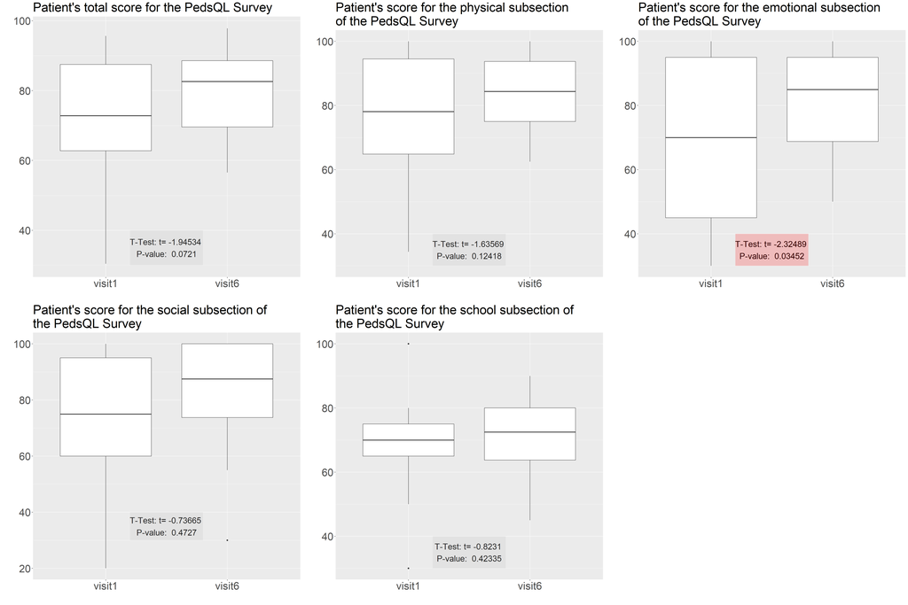

```r
#display the plots created above of the patients survey information
gridExtra::grid.arrange(grobs = pqlpatientplot, ncol=3) #patients pedsql survey results over 6 visits
```

##### PedsQL scores as evaluated by the patient’s parents reflected a similar change to the patients surveys as well. Again, highlighting the importance of such an intervention towards effecting a child’s emotional health.

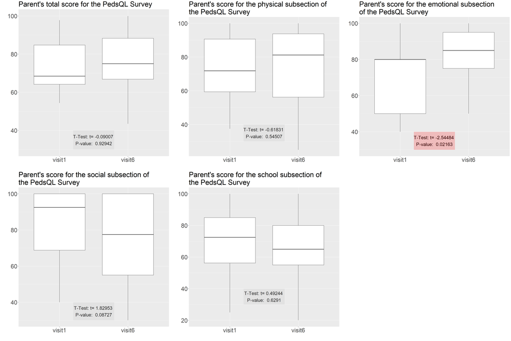

```r
gridExtra::grid.arrange(grobs = pqlparentplot, ncol=3) #parents pedsql survey results over 6 visits
```

##### Activity and nutrition survey results from patient surveys are displayed below for those that were significant or demonstrated a trend towards significance. Of those significant, two were not ideally what we would have preferred, that being an increase in hours of video games nd weekly fast-food intake. It is possible that patient’s were just more aware of their consumption after the intervention, but it would be something to consider for future planning. The increase in physical activity per week is certainly important. We would tend to argue that in younger children it may be more important to focus on physical activity than on food intake to avoid creating inappropriate thoughts and conceptions around food.

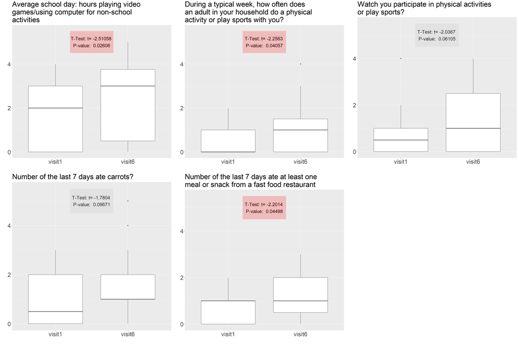

```r
gridExtra::grid.arrange(grobs = actNutriKids, ncol=3) #child's answers to activity and nutrition survey, first and last visits
```

##### Activity and nutrition surveys from parents were more encouraging. They stated that they encouraged their child to be more physically active, perhaps playing a role in children believing themselves to be more physically active. They also believed that their child ate more fruit and vegetables than prior to the study. We did not have a way to verify this, but even if it wasn’t true, the fact that the parents understood that it was important to try and get them to eat more fruits and vegetables is an important step to educating parents about what to feed their children.

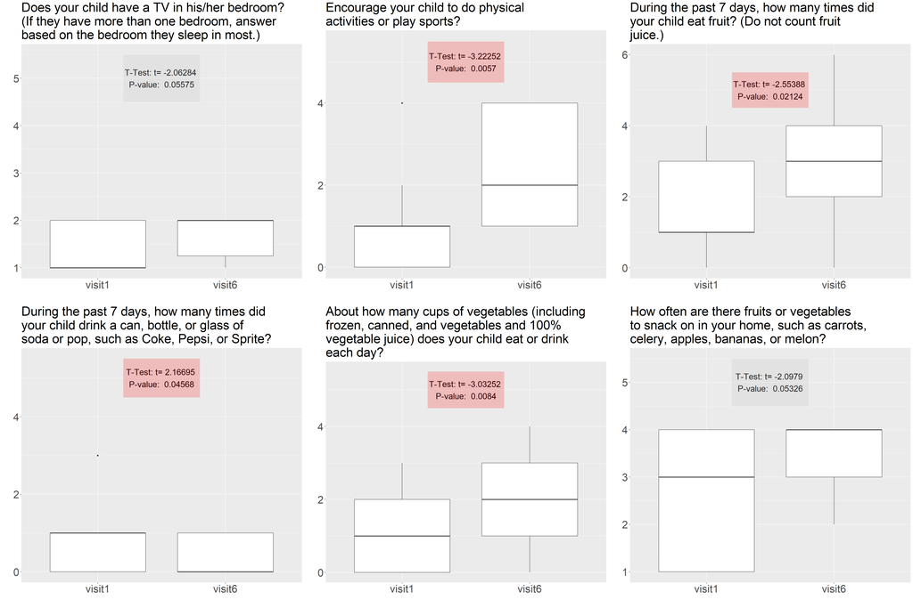

```r
gridExtra::grid.arrange(grobs = actNutriParents, ncol=3) #parent's answers to activity and nutrition survey, first and last visits
```

##### Once again, patient’s after the study felt that they were more physically active. This again agrees with their answers to the previous survey.

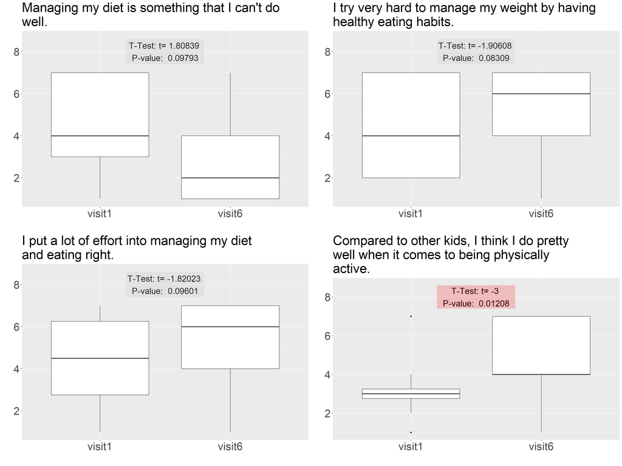

```r
gridExtra::grid.arrange(grobs = weightPts, ncol=2) #patient's answers to weight questionnaire, first and last visits
```

#### Linear regression was run on the the participants and on controls before and after the intervention started. These linear regression lines are displayed below for before and after the intervention for both controls and participants.

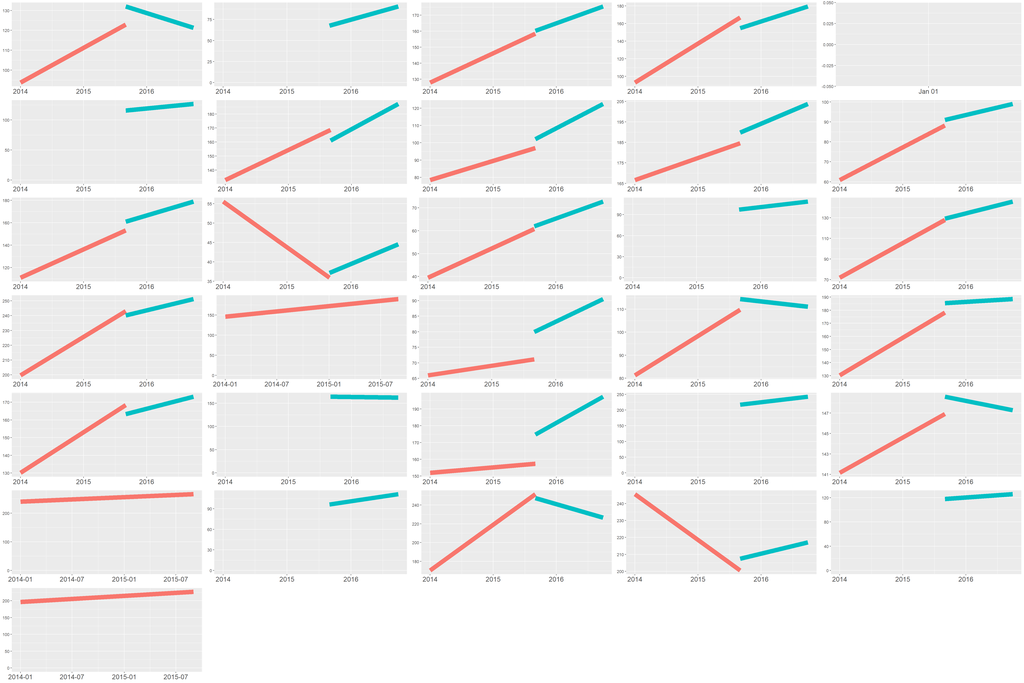

```r
#plot the weight changes for each participant and control
gridExtra::grid.arrange(grobs = wtplots, ncol=5)
```

#### However when the groups are compared, no statistically significant difference was found.

```r
#perform ttests on the different groups

#study participants pre and post intervention
t.test(studyprepost$slope.x, studyprepost$slope.y, alternative = "two.sided")$p.value
```

```
## [1] 0.149661
```

```r
#control participants pre and post intervention
t.test(controlprepost$slope.x, controlprepost$slope.y, alternative = "two.sided")$p.value
```

```
## [1] 0.2752352
```

```r
#study versus control pre intervention
t.test(studyprepost$slope.x, controlprepost$slope.x, alternative = "two.sided")$p.value
```

```
## [1] 0.5451327
```

```r
#study versus control post intervention
t.test(studyprepost$slope.y, controlprepost$slope.y, alternative = "two.sided")$p.value
```

```
## [1] 0.1349553
```

```r
#change in slope of linear regressions lines study versus control participants
studyprepost$diff <- studyprepost$slope.y - studyprepost$slope.x
controlprepost$diff <- controlprepost$slope.y - controlprepost$slope.x
t.test(studyprepost$diff, controlprepost$diff, alternative = "two.sided")$p.value
```

```
## [1] 0.8231871
```

### Conclusion

We felt that this was overall a reasonable result from a small pilot study. It is certainly underpowered to claim the value in the intervention definitively, but we do think that it demonstrates the value an feasability of studying such an intervention further.

It did seem to show for both children and their parents that their emotional health improved during this study. This might be the most important outcome of interventions such as this. Children’s emotional well-being plays a role in all aspects of their life, their health, and their future, being able to improve this with a relatively short and minor intervention could have signficiant long-term benefits.

Both children and their parents felt that they were more physically active after the study. Again, even if it’s just the perception would be a reasonable outcome. We could argue it demonstrates that both child and parent understand the importance of physical activity, and are trying to it more.

The actual diet might have possibly changed, but we think this is actually a less important outcome. Eating healthier does not mean never having fast food, and if the patient did eat more fruits and vegetables, even if they ate more fast food, this would still have a beneficial impact.

Lastly, the unchanged weight trajectories should not detract from any other findings. We understand more now that focusing on weight in children is almost always detrimental and should never be the focus of an intervention. If we were to repeat this study, we would put much less emphasis on this aspect.

Overall, we felt that our small pilot was successful, but certainly needs to be repeated on a larger to scale to show true demonstrable benefit.